# Visualization of CNN

Data Mining

# 클래스 활성화 히트맵 (Class Activation Map, CAM)

- 특정 클래스에 대해 입력 이미지의 모든 위치에 대해 계산된 2D 점수 그리드
- 모형에서 분류된 클래스에 대한 각 위치의 중요도
- 입력 이미지에 대해 합성곱 층에 있는 특성 맵의 출력을 추출하고 특성 맵의 모든 채널의 출력에 채널에 대한 클래스의 그래디언트 평균을 곱한다.
- ’클래스에 대한 각 채널의 중요도’로 가중치를 부여함으로써 공간적인 맵 형성

※ ImageNet의 사전 학습된 *VGG16* 모형을 사용해 이미지의 클래스를 예측하고 Grad-CAM을 이용해 클래스 활성화 히트맵을 계산한다.

#### Load Model

```r
model <- application_vgg16(weights = 'imagenet')
model
```

```
## Model
## ___________________________________________________________________________
## Layer (type)                     Output Shape                  Param #
## ===========================================================================
## input_1 (InputLayer)             (None, 224, 224, 3)           0
## ___________________________________________________________________________
## block1_conv1 (Conv2D)            (None, 224, 224, 64)          1792
## ___________________________________________________________________________
## block1_conv2 (Conv2D)            (None, 224, 224, 64)          36928
## ___________________________________________________________________________
## block1_pool (MaxPooling2D)       (None, 112, 112, 64)          0
## ___________________________________________________________________________
## block2_conv1 (Conv2D)            (None, 112, 112, 128)         73856
## ___________________________________________________________________________
## block2_conv2 (Conv2D)            (None, 112, 112, 128)         147584
## ___________________________________________________________________________
## block2_pool (MaxPooling2D)       (None, 56, 56, 128)           0
## ___________________________________________________________________________
## block3_conv1 (Conv2D)            (None, 56, 56, 256)           295168
## ___________________________________________________________________________
## block3_conv2 (Conv2D)            (None, 56, 56, 256)           590080
## ___________________________________________________________________________
## block3_conv3 (Conv2D)            (None, 56, 56, 256)           590080
## ___________________________________________________________________________
## block3_pool (MaxPooling2D)       (None, 28, 28, 256)           0
## ___________________________________________________________________________
## block4_conv1 (Conv2D)            (None, 28, 28, 512)           1180160
## ___________________________________________________________________________
## block4_conv2 (Conv2D)            (None, 28, 28, 512)           2359808
## ___________________________________________________________________________
## block4_conv3 (Conv2D)            (None, 28, 28, 512)           2359808
## ___________________________________________________________________________
## block4_pool (MaxPooling2D)       (None, 14, 14, 512)           0
## ___________________________________________________________________________
## block5_conv1 (Conv2D)            (None, 14, 14, 512)           2359808
## ___________________________________________________________________________
## block5_conv2 (Conv2D)            (None, 14, 14, 512)           2359808
## ___________________________________________________________________________
## block5_conv3 (Conv2D)            (None, 14, 14, 512)           2359808
## ___________________________________________________________________________
## block5_pool (MaxPooling2D)       (None, 7, 7, 512)             0
## ___________________________________________________________________________
## flatten (Flatten)                (None, 25088)                 0
## ___________________________________________________________________________
## fc1 (Dense)                      (None, 4096)                  102764544
## ___________________________________________________________________________
## fc2 (Dense)                      (None, 4096)                  16781312
## ___________________________________________________________________________
## predictions (Dense)              (None, 1000)                  4097000
## ===========================================================================
## Total params: 138,357,544
## Trainable params: 138,357,544
## Non-trainable params: 0
## ___________________________________________________________________________
```

#### Preprcoessing An Image to Array

```r
img_size <- 224

# 불러올 이미지의 이름
img_name <- 'African_elephant'

# 불러올 이미지의 디렉토리 경로
img_path <- glue('Image/{img_name}.jpg')

img <- image_load(img_path, target_size = c(img_size, img_size)) %>%
  image_to_array() %>%
  array_reshape(dim = c(1, img_size, img_size, 3)) %>%
  imagenet_preprocess_input()
```

이미지를 (1, 224, 224, 3) 크기의 배열로 변환하고 채널별 컬러 정규화를 수행한다.

#### Prediction & Interpretation

```r
img_pred <- model %>% predict(img)
decodeInfo <- imagenet_decode_predictions(img_pred, top = 5)[[1]]
decodeInfo
```

| class_name | class_description | score |
| --- | --- | --- |
| n02504458 | African_elephant | 0.9094210 |
| n01871265 | tusker | 0.0861829 |
| n02504013 | Indian_elephant | 0.0043546 |
| n02408429 | water_buffalo | 0.0000399 |
| n02397096 | warthog | 0.0000013 |

주어진 이미지 하나에 대해 예측된 확률이 가장 높은 Top-5 Class를 출력한다.

# Grad-CAM Process For an Image

#### Make a Function

```r
grad.cam <- function(img, model, layer_name, save = FALSE) {

  x <- img
  # 입력 이미지 x에 대한 예측확률 벡터 (각 클래스에 대한 스코어)
  pred_prob <- model %>% predict(x)

  # 스코어 가장 큰 클래스
  c <- which.max(pred_prob)

  # ------------------------- 연산을 위해 호출할 Tensor 정의 ------------------------- #
  # 모형의 마지막 합성곱 층
  last_conv_layer <- model %>% get_layer(layer_name)

  # 예측 벡터의 class c 항목
  x_output <- model$output[,c]

  # 입력 이미지 x에 대한 모형의 출력 값을
  # 마지막 합성곱 층에서 출력되는 특징 맵의 각 원소에 대해 편미분한 그래디언트
  grads <- k_gradients(loss = x_output,
                       variables = last_conv_layer$output)[[1]]

  # 개별 특징 맵 별 평균 그래디언트(강도)*
  # '하나의 특징맵이 클래스 c로 분류하는 데 기여하는 정도'를 의미한다.
  pooled_grads <- k_mean(grads, axis = c(1, 2, 3))
  # ---------------------------------------------------------------------------------- #

  # 정의한 Tensor들에 대해 실제로 값을 얻을 수 있도록 keras 함수를 정의한다.
  iterate <- k_function(inputs = list(model$input),
                        outputs = list(pooled_grads, last_conv_layer$output[1,,,]))

  # 함수를 실행해 실제로 입력 이미지 x에 대한 값을 얻는다.
  c(pooled_grads_value, conv_layer_output_value) %<-% iterate(list(x))

  # 마지막 합성곱 층에서 출력되는 특징 맵의 개수
  num_maps <- last_conv_layer$output_shape[[4]]

  # 마지막 합성곱 층에서 출력된 각 특징 맵의 원소에 계산된 평균 그래디언트(강도)를 곱해준다.
  for (i in 1:num_maps) {
    conv_layer_output_value[,,i] <- conv_layer_output_value[,,i] * pooled_grads_value[[i]]
  }

  # 특징 맵의 각 위치에 대해서 채널 방향으로 평균을 구한다. (channel-wise mean)
  # 클래스 활성화 기여도를 나타내는 히트맵***
  heatmap <- apply(conv_layer_output_value, c(1, 2), mean)

  # 시각화를 위해 양수만을 취하고 0-1 사이의 값으로 변환한다.
  heatmap <- pmax(heatmap, 0)
  heatmap <- heatmap / max(heatmap)

  decodeInfo <- imagenet_decode_predictions(pred_prob)[[1]]
  lab <- decodeInfo[1, 'class_description']
  cat('Predicted Label:', lab, '\n')

  # 계산된 히트맵 행렬을 CSV 파일로 저장하고자 할 경우
  if (save) {
    fname <- glue('Image/heatmap_{lab}.csv')
    write.csv(heatmap, fname, row.names = FALSE)
  }

  return(heatmap)
}
```

입력 이미지 하나에 대해 그래디언트에 기반한(Gradient-weighted) 클래스 활성화 히트맵을 계산하기 위한 함수를 정의한다.

#### Optain a Heatmap for an Image

```r
layer_name <- 'block5_conv3'
heatmap <- grad.cam(img, model, layer_name, save = TRUE)
```

```
## Predicted Label: African_elephant
```

```r
lab <- decodeInfo[1, 'class_description']
```

#### Heatmap

```r
write.heatmap <- function(heatmap, filename, width = img_size, height = img_size,
                          bg = 'white', col = viridis(12)) {
  png(filename, width = width, height = height, bg = bg)
  op = par(mar = c(0, 0, 0, 0))
  on.exit({par(op); dev.off()}, add = TRUE)
  rotate <- function(x) t(apply(x, 2, rev))
  image(rotate(heatmap), axes = FALSE, asp = 1, col = col)
}
```

```r
# 히트맵 이미지를 저장할 디렉토리 경로
heatmap_path <- glue('Image/heatmap_{lab}.png')
write.heatmap(heatmap, filename = heatmap_path)
```

얻어진 히트맵 그림을 파일로 저장한다.

## EXAMPLE

- ‘*African elephant*’ Class

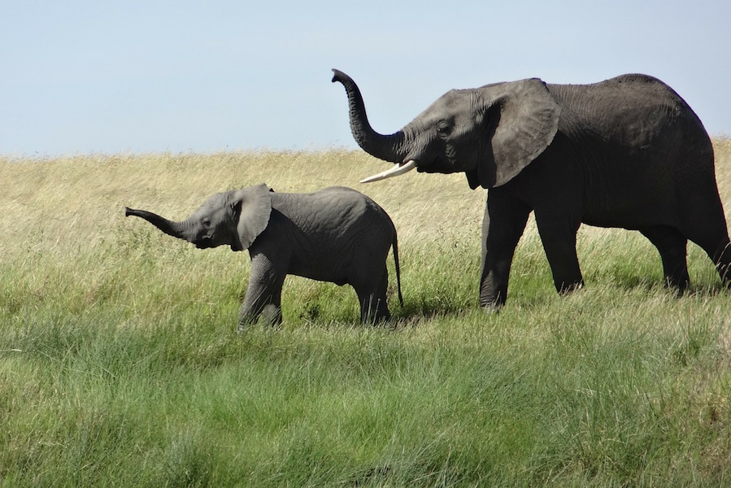

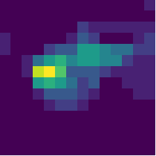

- ‘*golden retriever*’ Class

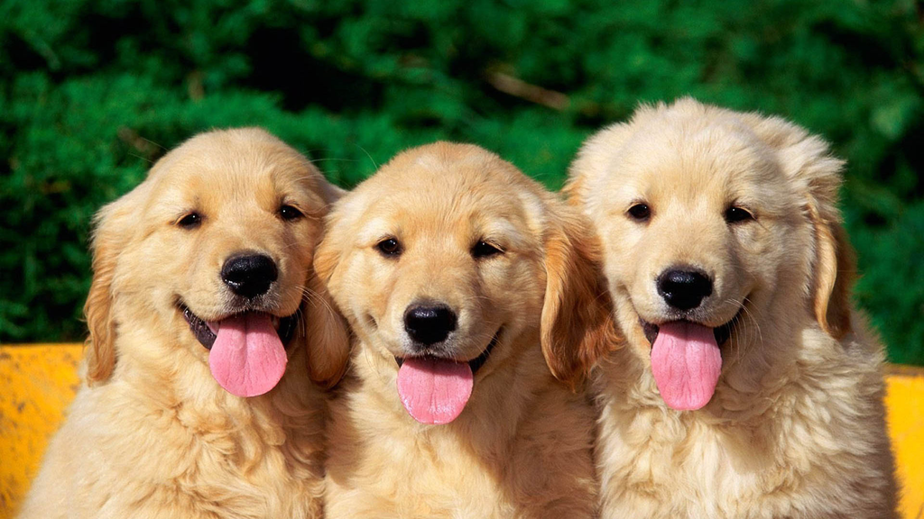

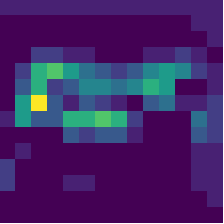

- ‘*racer*’ Class

[figure not shown]

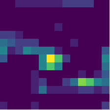

#### Overlayed Image

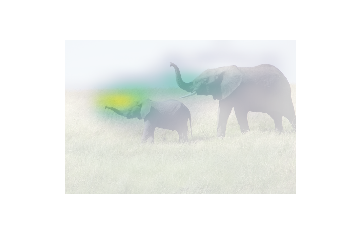

```r
draw.cam <- function(heatmap, img, label) {
  library(magick)
  library(viridis)

  cam_path <- cam_path <- glue('Image/cam_{label}_r.png')

  # Read the original image and it's geometry
  image <- image_read(img_path)
  info <- image_info(image)
  geometry <- sprintf("%dx%d!", info$width, info$height)

  # Create a blended / transparent version of the heatmap image
  pal <- col2rgb(viridis(20), alpha = TRUE)
  alpha <- floor(seq(0, 255, length = ncol(pal)))
  pal_col <- rgb(t(pal), alpha = alpha, maxColorValue = 255)

  write.heatmap(heatmap, cam_path,
                width = 14, height = 14, bg = NA, col = pal_col)
  # Overlay the heatmap
  cam <- image_read(cam_path) %>%
    image_resize(geometry, filter = "quadratic") %>%
    image_composite(image, operator = "blend", compose_args = "20")

  plot(cam)
}

draw.cam(heatmap, img, lab)
```